# CVC Workshop Notes

Simon Halliday

2015-July -13

Importing the medicare data…

```r
#medicare <- read.csv("/Users/shalliday/Google Drive/simondhalliday.github.io/cvc_workshop/medicare_fy2013.csv")
medicare <- read.csv("medicare_fy2013.csv")
#head(medicare)
#str(medicare)
```

Trying to embed a badly thought-out plot using the `ggvis` package:

```r
library(dplyr)
library(ggvis)
medicare %>%
  ggvis(~factor(Provider.State), ~Average.Covered.Charges) %>%
  layer_bars() %>%
   add_axis("x", properties = axis_props(
    labels = list(angle = 45, align = "left", fontSize = 10)
   ))
```

[output not shown]

## Teaching Tips

These are tips I picked out (thus peculiar to my tastes)

- **For teaching the idea of the command line and the script:** How many of you had a [TI calculator](https://en.wikipedia.org/wiki/Comparison_of_Texas_Instruments_graphing_calculators)? (TI = Texas Instruments) Did you know how to use it on the very first day? What about on your final day of high school? (RP)
- When R outputs the error `object '[object name]' not found` that normally means you (or your student) have mis-spelt the variable name or dataframe name. (RP)
- Pick your favorite way (command) for doing a job, don’t show students too many methods. You’ll overwhelm them if you give them too much. **Less volument, more creativity**. (RP)
- Call tildes `~` ‘wiggles’! Sounds funny and is less scary then tilde. (RP)
- Two most important questions: What do you want R to do? (goal) What must R know to do that? (RP) [me - why don’t I call R a specific name? e.g. R = Rachel - What do I want Rachel to do? What must Rachel know to do that?]
- Don’t teach them all the bells & whistles in a lecture when *you* want it. Rather, do it when they ask. (RP)
- Get students to adopt a **workflow** such that students can reproduce their work again with new data. (NH)
- When you start a new Markdown file (Rmd) means that you need to load each package in the Rmd file.

## Commonplace Book

- RP: “If your students find R to be the hardest part of your course, your R is too hard and your questions are too easy.”

## Commands to run

Scatterplot with birth data:

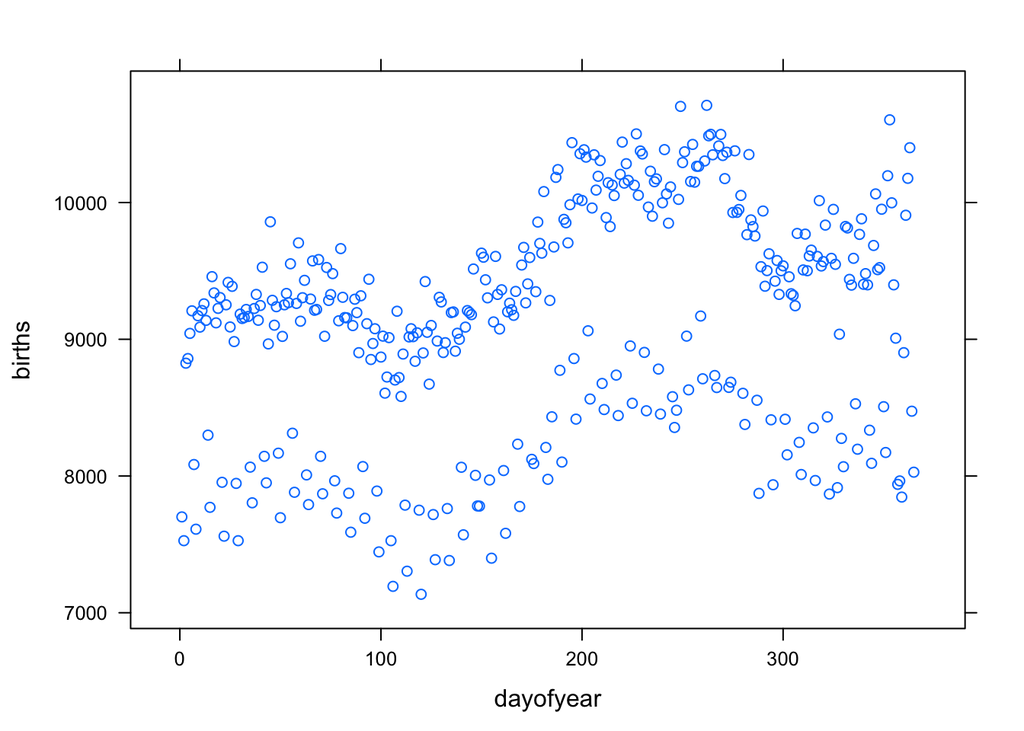

```r
library(mosaic)
library(mosaicData)
xyplot(births ~ dayofyear, data = Births78)
```

Other commands we’ve run during the workshop and some comments on them.

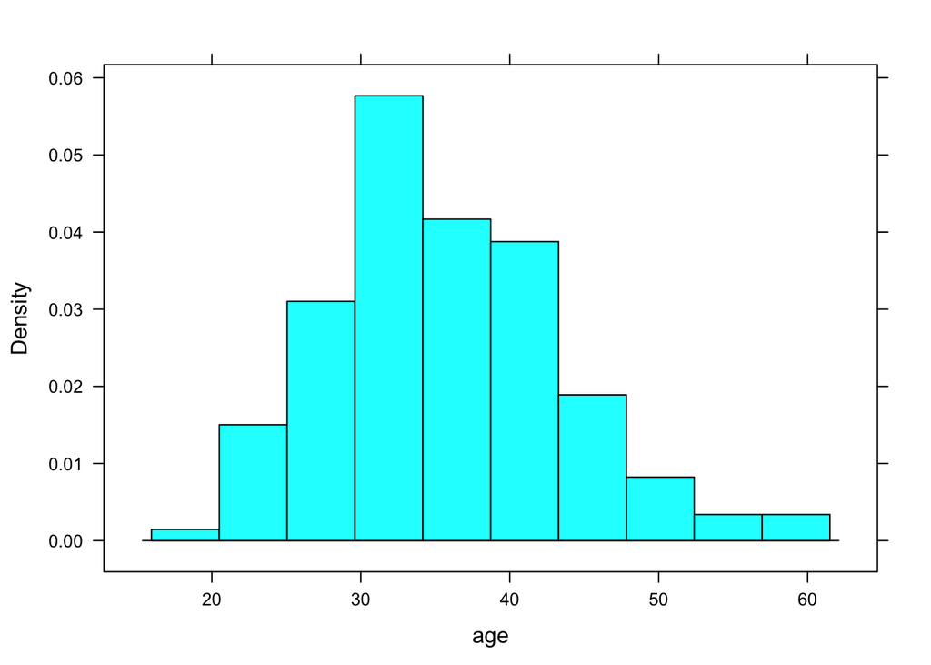

```r
histogram(~ age, data = HELPrct) #histogram of age
```

```r
favstats(~ age, data = HELPrct) #My favorite statistics; it ignores NAs
```

```
##  min Q1 median Q3 max     mean       sd   n missing
##   19 30     35 40  60 35.65342 7.710266 453       0
```

```r
tally(~sex, data = HELPrct) #Count of gender
```

```
##
## female   male
##    107    346
```

```r
tally(~sex, format = "percent", data = HELPrct) #Percents of gender
```

```
##
##   female     male
## 23.62031 76.37969
```

```r
tally(~sex, format = "proportion", data = HELPrct) #Proportions of gender
```

```
##
##    female      male
## 0.2362031 0.7637969
```

```r
tally(~substance, data = HELPrct) #Count of substance
```

```
##
## alcohol cocaine  heroin
##     177     152     124
```

```r
tally(~substance, format = "perc", data = HELPrct) #Percents of substance
```

```
##
##  alcohol  cocaine   heroin
## 39.07285 33.55408 27.37307
```

```r
tally(sex ~ substance, data = HELPrct) #Cross-tab sex & substance
```

```
##         substance
## sex      alcohol cocaine heroin
##   female      36      41     30
##   male       141     111     94
```

```r
tally(~ sex + substance, data = HELPrct) #Ditto, just a different format
```

```
##         substance
## sex      alcohol cocaine heroin
##   female      36      41     30
##   male       141     111     94
```

Also, always remember the `mplot` command for producing graphs and clicking on the ‘Show Expression’.